# Amazon Copurchased

This is a Python notebook created using "jupyter".

Author: Rafael J. P. dos Santos

## Parameters

We use the parameter below to set the maximum number of edges to be read from the CSV containing edges (links).

```python
max_edges = 500000 # Set quantity to read from file
edges_csv_file = "data/20180812_links"
nodes_csv_file = "data/20180812_nodes"
```

## Load the libraries

Let's load the Python libraries that we will need throughout the script

```python
import networkx as nx
import matplotlib.pyplot as plt
import pandas as pd
from sklearn.model_selection import train_test_split
import numpy as np
from sklearn.tree import export_graphviz
import pydot
from sklearn.ensemble import RandomForestRegressor
from __future__ import division
import sklearn
#from sklearn.cross_validation import cross_val_score
from sklearn.model_selection import cross_validate
from sklearn.metrics import make_scorer
import hashlib
import sys
print('The scikit-learn version is {}.'.format(sklearn.__version__))
```

```
The scikit-learn version is 0.20.2.
```

## Read graph

### Read only first lines of datafile

Due to slowness in calculating centrality measures, we use the parameter provided in the beggining of the script to limit the number of edges we will read.

```python
lines = []
total_line_count = 0
with open(edges_csv_file, 'rb') as f:
    f.readline()   # skip first line / header
    while True:
        line = f.readline()
        if not line:
            break
        if not (max_edges > 0 and len(lines) >= max_edges):
            lines.append(line)
        total_line_count += 1
G = nx.parse_edgelist(lines, delimiter=',', nodetype=int)
```

```python
print "Using %d edges out of %d available (%.2f%% of data)" % (len(lines), total_line_count, len(lines)/total_line_count * 100)
```

```
Using 229338 edges out of 229338 available (100.00% of data)
```

### Calculate nodes centrality measures

Now that we have our NetworkX graph, let's calculate some centrality measures for every node.

```python
centrality_measures = {}
```

#### Degree

```python
centrality_measures["degree"] = nx.degree(G)
```

#### Eigenvector centrality

```python
centrality_measures["eigenvector_centrality"] = nx.eigenvector_centrality_numpy(G)
```

#### Approximate betweenness centrality (current flow)

```python
centrality_measures["betweenness_centrality"] = nx.approximate_current_flow_betweenness_centrality(G)
```

#### Closeness centrality

```python
# Very slow!
centrality_measures["closeness_centrality"] = nx.closeness_centrality(G)
```

#### Betweenness centrality

```python
# Very slow!
centrality_measures["betweenness_centrality"] = nx.betweenness_centrality(G)
```

### Load node properties

Let's load the CSV containing the nodes data (title, price) into a Pandas dataframe, and append the centrality measures calculated above.

```python
df = pd.read_csv(nodes_csv_file)
```

#### Convert ID to random int to avoid leaking knowledge

```python
sha256_ids = df['id'].map(lambda x: int(hashlib.sha256(str(x)).hexdigest()[0:8], 16))
```

```python
# Add columns to dataframe
def merge_columns(dataframe, data):
    df = dataframe.copy()
    for col in data:
        rows = []
        for item in data[col].items():
            rows.append({"id": item[0], col: item[1]})
        df = df.merge(pd.DataFrame(rows))
    return df

df = merge_columns(df, centrality_measures)
df = merge_columns(df, {'sha256_id': sha256_ids})
```

### Let's convert some fields to numeric

```python
categorical_features = [
    'category1',
    'category2',
    'category3',
    'category4',
    'category5',
    'category6',
    'category7',
    'category8',
    'category9',
    'category10',
    'language',
    'coverType',
    'publisher',
    'rankingCategory',
    'authors'
]

numeric_features = [
    'degree',
    'eigenvector_centrality',
    'betweenness_centrality',
    'ranking',
    'reviewCount',
    'pages',
    'weight',
    'height',
    'width',
    'depth',
    'rating'
]

df = df.replace("<<MISSING_DATA>>", np.NaN)
df[numeric_features] = df[numeric_features].apply(pd.to_numeric)
df[['price']] = df[['price']].apply(pd.to_numeric)

for feature in numeric_features:
    df[feature].fillna(df[feature].mean(), inplace = True)
```

### Remove nodes without price

```python
df = df.drop(df[df["price"].isnull()].index)
#df = df.drop(df[df["price"] > 500].index)
```

### Inspect columns

```python
df.columns
```

```
Index([u'id', u'title', u'url', u'authors', u'coverType', u'publisher',
       u'edition', u'publicationDate', u'rankingCategory', u'category1',
       u'category2', u'category3', u'category4', u'category5', u'category6',
       u'category7', u'category8', u'category9', u'category10', u'isbn10',
       u'isbn13', u'language', u'postProcessed', u'price', u'ranking',
       u'pages', u'reviewCount', u'rating', u'width', u'height', u'depth',
       u'weight', u'eigenvector_centrality', u'degree',
       u'betweenness_centrality', u'sha256_id'],
      dtype='object')
```

### Features summary

Below we have a summary of the Pandas dataframe. We can see the number of nodes that we are actually analyzing, which depends on the max_edges parameter defined before.

```python
pd.set_option('display.max_columns', None)
#df.describe(include='all')
df.describe(include='all', percentiles=[0.25, 0.5, 0.75, 0.85, 0.9, 0.95, 0.99])
```

|  | id | title | url | authors | coverType | publisher | edition | publicationDate | rankingCategory | category1 | category2 | category3 | category4 | category5 | category6 | category7 | category8 | category9 | category10 | isbn10 | isbn13 | language | postProcessed | price | ranking | pages | reviewCount | rating | width | … |
| --- | --- | --- | --- | --- | --- | --- | --- | --- | --- | --- | --- | --- | --- | --- | --- | --- | --- | --- | --- | --- | --- | --- | --- | --- | --- | --- | --- | --- | --- | --- |
| count | 9153.000000 | 9153 | 9153 | 9152 | 9035 | 9052 | 0.0 | 783 | 8820 | 8707 | 8707 | 6525 | 3345 | 1205 | 188 | 17 | 0.0 | 0.0 | 0.0 | 9055 | 9055 | 9050 | 9153.0 | 9153.000000 | 9153.000000 | 9153.000000 | 9153.000000 | 9153.000000 | 9153.000000 | … |
| unique | NaN | 8952 | 9153 | 6177 | 11 | 728 | NaN | 574 | 1 | 1 | 28 | 228 | 440 | 309 | 71 | 8 | NaN | NaN | NaN | 9055 | 9055 | 7 | NaN | NaN | NaN | NaN | NaN | NaN | NaN | … |
| top | NaN | Macroeconomia | https://www.amazon.com.br/dp/8580332990/ | Vários Autores (Autor) | Capa comum | Companhia das Letras | NaN | 1 de janeiro de 2014 | Livros | Livros | Política, Filosofia e Ciências Sociais | Filosofia | Matemática | Brasil | Probabilidade e Estatística | Neurociência | NaN | NaN | NaN | 8525431494 | 978-8582600481 | Português | NaN | NaN | NaN | NaN | NaN | NaN | NaN | … |
| freq | NaN | 6 | 1 | 106 | 7729 | 536 | NaN | 13 | 8820 | 8707 | 1557 | 914 | 165 | 78 | 18 | 4 | NaN | NaN | NaN | 1 | 1 | 7976 | NaN | NaN | NaN | NaN | NaN | NaN | NaN | … |
| mean | 4896.658473 | NaN | NaN | NaN | NaN | NaN | NaN | NaN | NaN | NaN | NaN | NaN | NaN | NaN | NaN | NaN | NaN | NaN | NaN | NaN | NaN | NaN | 1.0 | 71.900469 | 35581.243023 | 352.333450 | 14.392313 | 4.443767 | 15.276002 | … |
| std | 2826.520995 | NaN | NaN | NaN | NaN | NaN | NaN | NaN | NaN | NaN | NaN | NaN | NaN | NaN | NaN | NaN | NaN | NaN | NaN | NaN | NaN | NaN | 0.0 | 145.716338 | 45683.667822 | 249.857638 | 32.650533 | 0.551851 | 2.574086 | … |
| min | 1.000000 | NaN | NaN | NaN | NaN | NaN | NaN | NaN | NaN | NaN | NaN | NaN | NaN | NaN | NaN | NaN | NaN | NaN | NaN | NaN | NaN | NaN | 1.0 | 2.900000 | 3.000000 | 2.000000 | 1.000000 | 1.000000 | 0.800000 | … |
| 25% | 2481.000000 | NaN | NaN | NaN | NaN | NaN | NaN | NaN | NaN | NaN | NaN | NaN | NaN | NaN | NaN | NaN | NaN | NaN | NaN | NaN | NaN | NaN | 1.0 | 26.310000 | 8345.000000 | 192.000000 | 2.000000 | 4.400000 | 13.600000 | … |
| 50% | 4900.000000 | NaN | NaN | NaN | NaN | NaN | NaN | NaN | NaN | NaN | NaN | NaN | NaN | NaN | NaN | NaN | NaN | NaN | NaN | NaN | NaN | NaN | 1.0 | 39.110000 | 22980.000000 | 304.000000 | 10.000000 | 4.445241 | 15.304075 | … |
| 75% | 7348.000000 | NaN | NaN | NaN | NaN | NaN | NaN | NaN | NaN | NaN | NaN | NaN | NaN | NaN | NaN | NaN | NaN | NaN | NaN | NaN | NaN | NaN | 1.0 | 63.110000 | 45609.000000 | 432.000000 | 14.304266 | 4.800000 | 16.000000 | … |
| 85% | 8326.200000 | NaN | NaN | NaN | NaN | NaN | NaN | NaN | NaN | NaN | NaN | NaN | NaN | NaN | NaN | NaN | NaN | NaN | NaN | NaN | NaN | NaN | 1.0 | 90.572000 | 63152.400000 | 544.000000 | 14.304266 | 5.000000 | 17.000000 | … |
| 90% | 8813.800000 | NaN | NaN | NaN | NaN | NaN | NaN | NaN | NaN | NaN | NaN | NaN | NaN | NaN | NaN | NaN | NaN | NaN | NaN | NaN | NaN | NaN | 1.0 | 120.744000 | 78753.400000 | 624.000000 | 20.000000 | 5.000000 | 18.980000 | … |
| 95% | 9294.400000 | NaN | NaN | NaN | NaN | NaN | NaN | NaN | NaN | NaN | NaN | NaN | NaN | NaN | NaN | NaN | NaN | NaN | NaN | NaN | NaN | NaN | 1.0 | 193.970000 | 107340.000000 | 784.000000 | 43.000000 | 5.000000 | 20.800000 | … |
| 99% | 9671.480000 | NaN | NaN | NaN | NaN | NaN | NaN | NaN | NaN | NaN | NaN | NaN | NaN | NaN | NaN | NaN | NaN | NaN | NaN | NaN | NaN | NaN | 1.0 | 723.754400 | 245419.320000 | 1196.880000 | 134.000000 | 5.000000 | 22.200000 | … |
| max | 9770.000000 | NaN | NaN | NaN | NaN | NaN | NaN | NaN | NaN | NaN | NaN | NaN | NaN | NaN | NaN | NaN | NaN | NaN | NaN | NaN | NaN | NaN | 1.0 | 2531.070000 | 438525.000000 | 4804.000000 | 755.000000 | 5.000000 | 35.500000 | … |

Below we can inspect the first rows of data, containing title, price, degree and other centrality measures.

```python
df.head(10)
```

|  | id | title | url | authors | coverType | publisher | edition | publicationDate | rankingCategory | category1 | category2 | category3 | category4 | category5 | category6 | category7 | category8 | category9 | category10 | isbn10 | isbn13 | language | postProcessed | price | ranking | pages | reviewCount | rating | width | … |
| --- | --- | --- | --- | --- | --- | --- | --- | --- | --- | --- | --- | --- | --- | --- | --- | --- | --- | --- | --- | --- | --- | --- | --- | --- | --- | --- | --- | --- | --- | --- |
| 0 | 1 | The Stanford Mathematics Problem Book: With Hi... | https://www.amazon.com.br/dp/0486469247/ | George Polya (Autor), | Capa comum | Dover Publications | NaN | 19 de fevereiro de 2009 | Livros | Livros | Inglês e Outras Línguas | Ciências Tecnológicas | Matemática | Estudo e Ensino | NaN | NaN | NaN | NaN | NaN | 0486469247 | 978-0486469249 | Inglês | 1 | 26.25 | 59183.0 | 68.0 | 1.000000 | 4.000000 | 14.0 | … |
| 1 | 2 | Fourier Series | https://www.amazon.com.br/dp/0486633179/ | Georgi P. Tolstov (Autor), | Capa comum | Dover Publications | NaN | 1 de junho de 1976 | Livros | Livros | Inglês e Outras Línguas | Ciências Tecnológicas | Matemática | Aplicada | Probabilidade e Estatística | NaN | NaN | NaN | NaN | 0486633179 | 978-0486633176 | Inglês | 1 | 50.37 | 56112.0 | 352.0 | 3.000000 | 4.600000 | 14.6 | … |
| 2 | 3 | Probability Theory: A Concise Course | https://www.amazon.com.br/dp/0486635449/ | Y. A. Rozanov (Autor), | Capa comum | Dover Publications | NaN | NaN | Livros | Livros | Inglês e Outras Línguas | Ciências Tecnológicas | Matemática | Aplicada | Probabilidade e Estatística | NaN | NaN | NaN | NaN | 0486635449 | 978-0486635446 | Inglês | 1 | 29.23 | 44345.0 | 160.0 | 14.304266 | 4.445241 | 14.4 | … |
| 3 | 4 | Vectors, Tensors and the Basic Equations of Fl... | https://www.amazon.com.br/dp/0486661105/ | Rutherford Aris (Autor), | Capa comum | Dover Publications | NaN | NaN | Livros | Livros | Inglês e Outras Línguas | Engenharia e Transporte | Engenharia | Mecânica | Hidráulica | NaN | NaN | NaN | NaN | 0486661105 | 978-0486661100 | Inglês | 1 | 48.79 | 82275.0 | 320.0 | 2.000000 | 4.500000 | 13.7 | … |
| 4 | 5 | Ordinary Differential Equations | https://www.amazon.com.br/dp/0486649407/ | Morris Tenenbaum (Autor), | Capa comum | Dover Publications | NaN | NaN | Livros | Livros | Inglês e Outras Línguas | Ciências Tecnológicas | Matemática | Aplicada | Equações Diferenciais | NaN | NaN | NaN | NaN | 0486649407 | 978-0486649405 | Inglês | 1 | 71.63 | 40840.0 | 848.0 | 4.000000 | 4.500000 | 13.8 | … |
| 5 | 6 | The Variational Principles of Mechanics | https://www.amazon.com.br/dp/0486650677/ | Cornelius Lanczos (Autor), | Capa comum | Dover Publications | NaN | NaN | Livros | Livros | Inglês e Outras Línguas | Ciências Tecnológicas | Física | Mecânica | NaN | NaN | NaN | NaN | NaN | 0486650677 | 978-0486650678 | Inglês | 1 | 88.15 | 36960.0 | 418.0 | 1.000000 | 5.000000 | 13.8 | … |
| 6 | 7 | A First Look at Perturbation Theory | https://www.amazon.com.br/dp/0486675513/ | James G. Simmonds (Autor) | Capa comum | Dover Publications Inc. | NaN | NaN | Livros | Livros | Inglês e Outras Línguas | Ciências Tecnológicas | Matemática | Aplicada | Equações Diferenciais | NaN | NaN | NaN | NaN | 0486675513 | 978-0486675510 | Inglês | 1 | 36.10 | 37291.0 | 160.0 | 14.304266 | 4.445241 | 13.7 | … |
| 7 | 8 | Thermodynamics and the Kinetic Theory of Gases... | https://www.amazon.com.br/dp/0486414612/ | Wolfgang Pauli (Autor), | Capa comum | Dover Publications | NaN | 18 de outubro de 2010 | Livros | Livros | Inglês e Outras Línguas | Ciências Tecnológicas | Física | Dinâmica | Termodinâmica | NaN | NaN | NaN | NaN | 0486414612 | 978-0486414614 | Inglês | 1 | 26.01 | 24406.0 | 160.0 | 2.000000 | 5.000000 | 13.8 | … |
| 8 | 9 | Mechanics | https://www.amazon.com.br/dp/0486607542/ | Jacob P. Den Hartog (Autor), | Capa comum | Dover Publications | NaN | 1 de junho de 1961 | Livros | Livros | Inglês e Outras Línguas | Ciências Tecnológicas | Física | Mecânica | NaN | NaN | NaN | NaN | NaN | 0486607542 | 978-0486607542 | Inglês | 1 | 50.96 | 90609.0 | 480.0 | 14.304266 | 4.445241 | 13.6 | … |
| 9 | 10 | Statistical Thermodynamics | https://www.amazon.com.br/dp/0486661016/ | Erwin Schrodinger (Autor), | Capa comum | Dover Publications | NaN | NaN | Livros | Livros | Inglês e Outras Línguas | Ciências Tecnológicas | Física | Dinâmica | Termodinâmica | NaN | NaN | NaN | NaN | 0486661016 | 978-0486661018 | Inglês | 1 | 32.16 | 65112.0 | 112.0 | 14.304266 | 4.445241 | 14.0 | … |

## Random forest using various features, price as target

### Preparing data

```python
df_with_dummies = pd.get_dummies(df[['sha256_id'] + numeric_features + categorical_features + ['price']],columns=categorical_features,drop_first=True)
```

```python
feature_list = list(df_with_dummies.drop(columns = ['price']))

features_values = np.array(df_with_dummies.drop(columns = ['price']))
target_value = np.array(df_with_dummies['price'])

features_and_target = np.concatenate((features_values, target_value.reshape(len(target_value), 1)), axis = 1)

#print features_and_target.shape

# Shuffle features_and_target
np.random.shuffle(features_and_target)

limit = int(round(len(target_value) * 0.8))
print "Test percentage", (len(target_value)-limit)/len(target_value)

features = features_and_target[:limit, :-1]
target = features_and_target[:limit, -1]

test_features = features_and_target[limit:, :-1]
test_target = features_and_target[limit: , -1]

print "Train features shape", features.shape
print "Train target shape", target.shape
print "Test features shape", test_features.shape
print "Test target shape", test_target.shape
```

```
Test percentage 0.200043701519
Train features shape (7322, 8009)
Train target shape (7322,)
Test features shape (1831, 8009)
Test target shape (1831,)
```

### Average price as baseline

It's important to have a baseline, so we can validate our predictions after running our model. One easy choice for baseline is the average price of a book.

```python
average_target = np.average(target)
print "Average price: R$", average_target
```

```
Average price: R$ 71.18114449603934
```

### Cross val

#### Run cross val

```python
def baseline_score_function (y_true, y_pred):
    errors_baseline = abs(average_target - y_true)
    return np.mean(errors_baseline)

def relative_error_function (y_true, y_pred):
    errors_absolute = abs(y_pred - y_true)
    errors_relative = errors_absolute / y_true
    return np.mean(errors_relative)

def baseline_relative_error_function (y_true, y_pred):
    errors_absolute = abs(average_target - y_true)
    errors_relative = errors_absolute / y_true
    return np.mean(errors_relative)

rf = RandomForestRegressor(n_estimators = 50, n_jobs = -1)

scorer = make_scorer(baseline_score_function)
scorer2 = make_scorer(relative_error_function)
scorer3 = make_scorer(baseline_relative_error_function)

scores = cross_validate(estimator=rf, X=features, y=target, cv=10,
                        scoring = {
                            'abs': 'neg_mean_absolute_error',
                            'baseline': scorer,
                            'relative': scorer2,
                            'baseline_relative': scorer3
                        },
                        return_train_score=False, return_estimator = True)

# Use best estimator to do some visual reports
rf = scores['estimator'][0]
```

#### Cross val score

```python
print "=== Relative"
print "RF relative abs mean: ", np.mean(np.abs(scores['test_relative']))
print "RF relative abs std: ", np.std(scores['test_relative'])

#print "Baseline: ", scores['test_baseline']
print "Baseline relative mean: ", np.mean(scores['test_baseline_relative'])
print "Baseline relative std: ", np.std(scores['test_baseline_relative'])

print "=== Absolute"

#print "Abs: ", scores['test_abs']
print "RF abs mean: ", np.mean(np.abs(scores['test_abs']))
print "RF abs std: ", np.std(scores['test_abs'])

#print "Baseline: ", scores['test_baseline']
print "Baseline mean: ", np.mean(scores['test_baseline'])
print "Baseline std: ", np.std(scores['test_baseline'])
```

```
=== Relative
RF relative abs mean:  0.3388605550743672
RF relative abs std:  0.020927137702018744
Baseline relative mean:  1.3070363581828268
Baseline relative std:  0.04199560444097607
=== Absolute
RF abs mean:  22.246533465733304
RF abs std:  2.589229314762932
Baseline mean:  56.472392261557545
Baseline std:  5.6444698479582724
```

#### List of most important features

```python
importance = zip(feature_list, rf.feature_importances_)
importance.sort(key=lambda x:-x[1])
pd.DataFrame(importance).head(200)
```

|  | 0 | 1 |
| --- | --- | --- |
| 0 | language_Inglês | 0.186315 |
| 1 | pages | 0.186292 |
| 2 | category2_Inglês e Outras Línguas | 0.183115 |
| 3 | publisher_Cengage Learning | 0.060209 |
| 4 | height | 0.047300 |
| 5 | width | 0.044260 |
| 6 | eigenvector_centrality | 0.039685 |
| 7 | ranking | 0.034047 |
| 8 | coverType_Capa dura | 0.027920 |
| 9 | sha256_id | 0.017872 |
| 10 | coverType_Capa comum | 0.014310 |
| 11 | depth | 0.013516 |
| 12 | degree | 0.011599 |
| 13 | betweenness_centrality | 0.011053 |
| 14 | authors_Tom M. Mitchell (Autor), | 0.009743 |
| 15 | weight | 0.008998 |
| 16 | publisher_McGraw-Hill Science/Engineering/Math | 0.007600 |
| 17 | publisher_W.H. Freeman & Company | 0.007159 |
| 18 | authors_Jerrold E. Marsden (Autor), | 0.006511 |
| 19 | publisher_Pearson | 0.004534 |
| 20 | publisher_John Wiley & Sons | 0.003906 |
| 21 | authors_E. Artin (Autor) | 0.002635 |
| 22 | rating | 0.002622 |
| 23 | publisher_Wiley-Blackwell | 0.002608 |
| 24 | authors_Dr John H. Davies (Autor) | 0.002602 |
| 25 | publisher_Cambridge University Press | 0.002256 |
| 26 | authors_J.M. Smith Termodinamica en ingenieria... | 0.002068 |
| 27 | authors_Peter J. Eccles (Autor) | 0.001967 |
| 28 | authors_S. M. Neill C. M. Ridley (Autor) | 0.001953 |
| 29 | publisher_Addison Wesley Longman | 0.001794 |
| ... | ... | ... |
| 170 | authors_Elias M. Stein (Autor), | 0.000064 |
| 171 | authors_Dave Goldberg (Autor) | 0.000064 |
| 172 | authors_Nelson Nery Junior (Autor), | 0.000063 |
| 173 | authors_Bruce Dang (Autor), | 0.000061 |
| 174 | authors_Theodore Frankel (Autor) | 0.000061 |
| 175 | category5_Teoria Quântica | 0.000061 |
| 176 | category3_Educação e Desenvolvimento Profissional | 0.000061 |
| 177 | authors_James Ward Brown (Autor), | 0.000061 |
| 178 | publisher_Sams Publishing | 0.000060 |
| 179 | authors_Alfredo Steimbruch (Autor), | 0.000060 |
| 180 | publisher_Alta Books | 0.000058 |
| 181 | publisher_FCA | 0.000058 |
| 182 | authors_Michael Tsamparlis (Autor) | 0.000057 |
| 183 | category5_Mecânica | 0.000057 |
| 184 | category2_Religião e Espiritualidade | 0.000057 |
| 185 | authors_Hall John E. (Autor) | 0.000057 |
| 186 | category5_Algoritmos | 0.000056 |
| 187 | category3_Medicina Veterinária | 0.000056 |
| 188 | authors_Peter Atkins (Autor), | 0.000056 |
| 189 | publisher_Garland Publishing | 0.000055 |
| 190 | authors_Miguel Rocha (Autor), | 0.000055 |
| 191 | publisher_AK Peters | 0.000053 |
| 192 | authors_Frank Jensen (Autor) | 0.000053 |
| 193 | authors_Thomas H. Cormen (Autor), | 0.000053 |
| 194 | category6_GRE | 0.000053 |
| 195 | category3_Engenharia | 0.000053 |
| 196 | authors_Ariel Rubinstein (Posfácio), | 0.000051 |
| 197 | category6_Topologia | 0.000051 |
| 198 | category2_Engenharia e Transporte | 0.000051 |
| 199 | authors_OTTO MARIA CARPEAUX (Autor) | 0.000050 |

200 rows × 2 columns

## Test dataset and visual inspection

```python
test_predictions = rf.predict(test_features)
```

### Predicted price vs real price

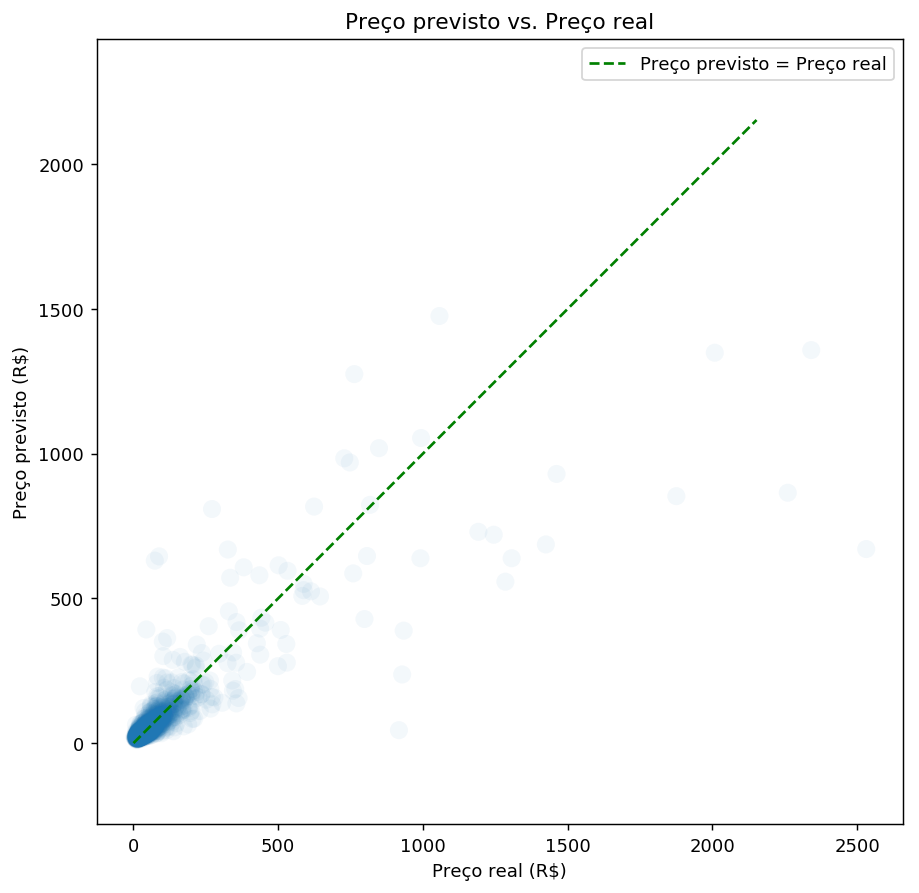

```python
plt.figure(figsize=(8,8), dpi=130)
plt.scatter(test_target, test_predictions, 100, alpha=0.05, edgecolors="none")
baseline = [0, np.max(target)]
plt.plot(baseline, baseline, "--", color="green", label = u"Preço previsto = Preço real")
ax = plt.gca()
ax.set_ylabel(u"Preço previsto (R$)")
ax.set_xlabel(u"Preço real (R$)")
ax.legend()
plt.title(u"Preço previsto vs. Preço real")
plt.axes().set_aspect('equal', 'datalim')
#plt.xlim(0, 150)
#plt.ylim(0, 150)
plt.show()
```

### Mean absolute error

Now we can compare the errors obtained by our predictions against the errors provided by the baseline (average price). Our prediction errors should be less than the baseline errors to consider the model successful.

```python
# Calculate the absolute errors
errors = abs(test_predictions - test_target)
errors_baseline = abs(average_target - test_target)
errors_relative = errors/test_target
errors_baseline_relative = errors_baseline/test_target
# Print out the mean absolute error (mae)
print "== Absolute"
print('Mean absolute prediction error: R$', round(np.mean(errors), 2))
print('Std prediction error: R$', round(np.std(errors), 2))
print('Mean absolute error using average: R$', round(np.mean(errors_baseline), 2))
print('Std prediction error using average: R$', round(np.std(errors_baseline), 2))
print "== Relative"
print('Mean relative absolute prediction error: ', round(np.mean(errors_relative), 2))
print('Std relative prediction error: ', round(np.std(errors_relative), 2))
print('Mean relative absolute error using average: ', round(np.mean(errors_baseline_relative), 2))
print('Std relative prediction error using average: ', round(np.std(errors_baseline_relative), 2))
```

```
== Absolute
('Mean absolute prediction error: R$', 24.72)
('Std prediction error: R$', 88.59)
('Mean absolute error using average: R$', 61.21)
('Std prediction error using average: R$', 154.01)
== Relative
('Mean relative absolute prediction error: ', 0.34)
('Std relative prediction error: ', 0.55)
('Mean relative absolute error using average: ', 1.35)
('Std relative prediction error using average: ', 1.53)
```

### Join data

```python
pd.set_option('display.max_columns', None)
data = {
    "all_features": test_features.tolist(),
    "sha256_id": test_features[:, 0],
    "target": test_target,
    "prediction": test_predictions,
    "error": errors,
    "error_relative": errors_relative,
    "error_baseline": errors_baseline,
    "error_baseline_relative": errors_baseline_relative
}
predicted_df = pd.DataFrame(data = data)
joined_predicted_df = predicted_df
joined_predicted_df = predicted_df.set_index("sha256_id").join(df.set_index("sha256_id"))
```

### Worst absolute predictions

Below we can inspect the rows with the biggest prediction error.

```python
joined_predicted_df.sort_values('error', ascending = False).head(20)
```

| sha256_id | all_features | error | error_baseline | error_baseline_relative | error_relative | prediction | target | id | title | url | authors | coverType | publisher | edition | publicationDate | rankingCategory | category1 | category2 | category3 | category4 | category5 | category6 | category7 | category8 | category9 | category10 | isbn10 | isbn13 | language | … |
| --- | --- | --- | --- | --- | --- | --- | --- | --- | --- | --- | --- | --- | --- | --- | --- | --- | --- | --- | --- | --- | --- | --- | --- | --- | --- | --- | --- | --- | --- | --- |
| 4.565469e+08 | [456546893.0, 40.0, 2.32915250068e-06, 0.00062... | 1860.8522 | 2459.888856 | 0.971877 | 0.735204 | 670.2178 | 2531.07 | 1685 | Complex Analysis Complex Analysis Complex Anal... | https://www.amazon.com.br/dp/0070006571/ | Lars V. Ahlfors (Autor), | Capa dura | McGraw-Hill Science/Engineering/Math | NaN | NaN | NaN | NaN | NaN | NaN | NaN | NaN | NaN | NaN | NaN | NaN | NaN | 0070006571 | 978-0070006577 | Inglês | … |
| 2.300254e+09 | [2300254391.0, 24.0, 5.67619962654e-07, 0.0008... | 1395.4424 | 2188.928856 | 0.968505 | 0.617422 | 864.6676 | 2260.11 | 2202 | Lehninger Principles of Biochemistry | https://www.amazon.com.br/dp/1464126119/ | David L. Nelson (Autor), | Capa dura | W. H. Freeman | NaN | NaN | Livros | Livros | Inglês e Outras Línguas | Ciências Tecnológicas | Ciências Biológicas | Bioquímica | NaN | NaN | NaN | NaN | NaN | 1464126119 | 978-1464126116 | Inglês | … |
| 5.708639e+08 | [570863889.0, 24.0, 6.00364756039e-07, 0.00085... | 1022.2508 | 1803.998856 | 0.962040 | 0.545148 | 852.9292 | 1875.18 | 2201 | Lehninger Principles of Biochemistry | https://www.amazon.com.br/dp/1429234148/ | David L. Nelson (Autor), | Capa dura | W. H. Freeman | NaN | NaN | Livros | Livros | Inglês e Outras Línguas | Ciências Tecnológicas | Ciências Biológicas | Bioquímica | NaN | NaN | NaN | NaN | NaN | 1429234148 | 978-1429234146 | Inglês | … |
| 1.731114e+09 | [1731113829.0, 35.0, 2.75530196118e-06, 0.0011... | 983.7536 | 2270.018856 | 0.969596 | 0.420192 | 1357.4464 | 2341.20 | 1779 | Modern Physics for Scientists and Engineers | https://www.amazon.com.br/dp/1133103723/ | Stephen T. Thornton (Autor), | Capa dura | Cengage Learning | NaN | NaN | NaN | NaN | NaN | NaN | NaN | NaN | NaN | NaN | NaN | NaN | NaN | 1133103723 | 978-1133103721 | Inglês | … |
| 2.245409e+09 | [2245408859.0, 2.0, 2.39903327313e-07, 8.60237... | 872.3846 | 845.768856 | 0.922372 | 0.951398 | 44.5654 | 916.95 | 1965 | Introduction to Quantum Mechanics | https://www.amazon.com.br/dp/0131118927/ | David J. Griffiths (Autor) | NaN | NaN | NaN | NaN | NaN | NaN | NaN | NaN | NaN | NaN | NaN | NaN | NaN | NaN | NaN | NaN | NaN | NaN | … |
| 3.827285e+09 | [3827285417.0, 59.0, 1.65716636246e-06, 0.0009... | 738.3214 | 1353.258856 | 0.950029 | 0.518324 | 686.1186 | 1424.44 | 1692 | Linear Algebra and Its Applications plus New M... | https://www.amazon.com.br/dp/0134022696/ | David C. Lay (Autor), | Capa dura | Pearson | NaN | NaN | NaN | NaN | NaN | NaN | NaN | NaN | NaN | NaN | NaN | NaN | NaN | 0134022696 | 978-0134022697 | Inglês | … |
| 2.187742e+09 | [2187741581.0, 19.0, 6.13810159462e-07, 0.0005... | 727.1688 | 1213.438856 | 0.944590 | 0.566058 | 557.4512 | 1284.62 | 1952 | Advanced Engineering Mathematics | https://www.amazon.com.br/dp/0470458364/ | Erwin Kreyszig (Autor) | Capa dura | Wiley | NaN | NaN | Livros | Livros | Inglês e Outras Línguas | Ciências Tecnológicas | Matemática | Aplicada | NaN | NaN | NaN | NaN | NaN | 0470458364 | 978-0470458365 | Inglês | … |
| 1.285898e+08 | [128589845.0, 35.0, 2.10021972578e-05, 0.00147... | 691.1182 | 856.858856 | 0.923299 | 0.744707 | 236.9218 | 928.04 | 2247 | The Undivided Universe | https://www.amazon.com.br/dp/0415065887/ | David Bohm (Autor), | Capa dura | Routledge | NaN | NaN | NaN | NaN | NaN | NaN | NaN | NaN | NaN | NaN | NaN | NaN | NaN | 0415065887 | 978-0415065887 | Inglês | … |
| 1.378771e+09 | [1378771352.0, 24.0, 9.30486894025e-07, 0.0014... | 667.9272 | 1235.168856 | 0.945511 | 0.511293 | 638.4228 | 1306.35 | 1924 | Fundamentals of Applied Electromagnetics | https://www.amazon.com.br/dp/0133356817/ | Fawwaz T. Ulaby (Autor), | Capa dura | Prentice Hall | NaN | NaN | NaN | NaN | NaN | NaN | NaN | NaN | NaN | NaN | NaN | NaN | NaN | 0133356817 | 978-0133356816 | Inglês | … |
| 4.056917e+09 | [4056917483.0, 13.0, 1.79587430218e-07, 0.0002... | 659.5920 | 1936.738856 | 0.964550 | 0.328495 | 1348.3280 | 2007.92 | 1970 | Physics for Scientists and Engineers: A Strate... | https://www.amazon.com.br/dp/0133953149/ | Randall D. Knight (Professor Emeritus) (Autor) | Capa dura | Pearson | NaN | NaN | NaN | NaN | NaN | NaN | NaN | NaN | NaN | NaN | NaN | NaN | NaN | 0133953149 | 978-0133953145 | Inglês | … |
| 2.644459e+09 | [2644458574.0, 24.0, 5.33065555691e-06, 0.0008... | 556.5894 | 2.418856 | 0.032865 | 7.562356 | 630.1894 | 73.60 | 2169 | 100 Instructive Calculus-Based Physics Example... | https://www.amazon.com.br/dp/1941691137/ | Chris McMullen (Autor) | NaN | Zishka Publishing | NaN | 17 de maio de 2017 | NaN | NaN | NaN | NaN | NaN | NaN | NaN | NaN | NaN | NaN | NaN | 1941691137 | 978-1941691137 | Inglês | … |
| 8.719099e+08 | [871909854.0, 7.0, 1.9718932247e-07, 4.4813762... | 556.5858 | 17.118856 | 0.193872 | 6.303350 | 644.8858 | 88.30 | 2080 | Cracking the GRE with 4 Practice Tests, 2019 E... | https://www.amazon.com.br/dp/1524757918/ | Princeton Review (Autor) | Capa comum | Princeton Review | NaN | NaN | NaN | NaN | NaN | NaN | NaN | NaN | NaN | NaN | NaN | NaN | NaN | 1524757918 | 978-1524757915 | Inglês | … |
| 3.835611e+09 | [3835611206.0, 11.0, 1.88023241739e-06, 0.0001... | 544.9518 | 862.128856 | 0.923733 | 0.583892 | 388.3582 | 933.31 | 1774 | Electronics with Discrete Components | https://www.amazon.com.br/dp/0470889683/ | Enrique J. Galvez (Autor) | Capa dura | John Wiley & Sons | NaN | NaN | NaN | NaN | NaN | NaN | NaN | NaN | NaN | NaN | NaN | NaN | NaN | 0470889683 | 978-0470889688 | Inglês | … |
| 8.270974e+08 | [827097381.0, 14.0, 8.33359782825e-08, 0.00053... | 537.1216 | 200.078856 | 0.737591 | 1.980099 | 808.3816 | 271.26 | 2204 | Quantum Chemistry: Problems and Solutions | https://www.amazon.com.br/dp/1891389521/ | Helen O. Leung (Autor), | Capa comum | University Science Books | NaN | NaN | NaN | NaN | NaN | NaN | NaN | NaN | NaN | NaN | NaN | NaN | NaN | 1891389521 | 978-1891389528 | Inglês | … |
| 3.660084e+09 | [3660083613.0, 36.0, 5.28038789263e-07, 0.0004... | 531.8364 | 1390.248856 | 0.951293 | 0.363915 | 929.5936 | 1461.43 | 1778 | Materials Science and Engineering: An Introduc... | https://www.amazon.com.br/dp/1118324579/ | William D., Jr. Callister (Autor), | Capa dura | John Wiley & Sons | NaN | NaN | Livros | Livros | Inglês e Outras Línguas | Engenharia e Transporte | Engenharia | Ciência dos Materiais | NaN | NaN | NaN | NaN | NaN | 1118324579 | 978-1118324578 | Inglês | … |
| 5.445666e+08 | [544566571.0, 7.0, 6.15307448943e-07, 0.000177... | 524.8180 | 1173.248856 | 0.942800 | 0.421734 | 719.6120 | 1244.43 | 2072 | The Physics Companion, 2nd Edition | https://www.amazon.com.br/dp/1138429597/ | Anthony C. Fischer-Cripps (Autor) | NaN | CRC Press | NaN | NaN | NaN | NaN | NaN | NaN | NaN | NaN | NaN | NaN | NaN | NaN | NaN | 1138429597 | 978-1138429598 | Inglês | … |
| 3.928054e+09 | [3928053536.0, 7.0, 2.05958110313e-07, 8.79717... | 511.7996 | 691.518856 | 0.906672 | 0.671037 | 1274.4996 | 762.70 | 2198 | Principles of Inorganic Chemistry | https://www.amazon.com.br/dp/1118859103/ | Brian W. Pfennig (Autor) | Capa dura | Wiley-Blackwell | NaN | NaN | NaN | NaN | NaN | NaN | NaN | NaN | NaN | NaN | NaN | NaN | NaN | 1118859103 | 978-1118859100 | Inglês | … |
| 2.392549e+09 | [2392549009.0, 1.0, 7.46340835041e-08, 0.0, 20... | 461.6890 | 1120.148856 | 0.940251 | 0.387541 | 729.6410 | 1191.33 | 1955 | Handbook of Applied Hydrology, Second Edition | https://www.amazon.com.br/dp/0071835091/ | Vijay P. Singh (Autor) | Capa dura | McGraw-Hill Education | NaN | NaN | Livros | Livros | Inglês e Outras Línguas | Engenharia e Transporte | Engenharia | Civil | Ambiental | NaN | NaN | NaN | NaN | 0071835091 | 978-0071835091 | Inglês | … |
| 3.433301e+09 | [3433300775.0, 15.0, 2.76102021496e-07, 0.0001... | 418.3724 | 985.618856 | 0.932645 | 0.395886 | 1475.1724 | 1056.80 | 1768 | Mechanics of Materials | https://www.amazon.com.br/dp/0073398233/ | Ferdinand P. Beer (Autor), | Capa dura | McGraw-Hill Science/Engineering/Math | NaN | NaN | NaN | NaN | NaN | NaN | NaN | NaN | NaN | NaN | NaN | NaN | NaN | 0073398233 | 978-0073398235 | Inglês | … |
| 3.410416e+09 | [3410415506.0, 5.0, 2.07566931806e-06, 6.80605... | 369.3798 | 726.698856 | 0.910787 | 0.462952 | 428.5002 | 797.88 | 2253 | The Pauli Exclusion Principle: Origin, Verific... | https://www.amazon.com.br/dp/1118795326/ | Ilya G. Kaplan (Autor) | Capa dura | Wiley-Blackwell | NaN | NaN | NaN | NaN | NaN | NaN | NaN | NaN | NaN | NaN | NaN | NaN | NaN | 1118795326 | 978-1118795323 | Inglês | … |

### Worst relative predictions

```python
joined_predicted_df.sort_values('error_relative', ascending = False).head(20)
```

| sha256_id | all_features | error | error_baseline | error_baseline_relative | error_relative | prediction | target | id | title | url | authors | coverType | publisher | edition | publicationDate | rankingCategory | category1 | category2 | category3 | category4 | category5 | category6 | category7 | category8 | category9 | category10 | isbn10 | isbn13 | language | … |
| --- | --- | --- | --- | --- | --- | --- | --- | --- | --- | --- | --- | --- | --- | --- | --- | --- | --- | --- | --- | --- | --- | --- | --- | --- | --- | --- | --- | --- | --- | --- |
| 4.047607e+09 | [4047607377.0, 5.0, 0.000326623074221, 0.00104... | 174.0570 | 49.111144 | 2.225244 | 7.886588 | 196.1270 | 22.07 | 9312 | How to Win Friends & Influence People (Miniatu... | https://www.amazon.com.br/dp/0762462019/ | Dale Carnegie (Autor) | Capa dura | Running Press Miniature Editions | NaN | NaN | Livros | Livros | Inglês e Outras Línguas | Administração, Negócios e Economia | NaN | NaN | NaN | NaN | NaN | NaN | NaN | 0762462019 | 978-0762462018 | Inglês | … |
| 3.548407e+09 | [3548407309.0, 2.0, 2.30868987915e-06, 4.49863... | 348.1032 | 26.891144 | 0.607161 | 7.859634 | 392.3932 | 44.29 | 9183 | The Complete Fiction of H. P. Lovecraft | https://www.amazon.com.br/dp/0785834206/ | H. P. Lovecraft (Autor) | Capa dura | Chartwell Books | NaN | NaN | Livros | Livros | Inglês e Outras Línguas | Literatura e Ficção | Ficção | NaN | NaN | NaN | NaN | NaN | NaN | 0785834206 | 978-0785834205 | Inglês | … |
| 2.644459e+09 | [2644458574.0, 24.0, 5.33065555691e-06, 0.0008... | 556.5894 | 2.418856 | 0.032865 | 7.562356 | 630.1894 | 73.60 | 2169 | 100 Instructive Calculus-Based Physics Example... | https://www.amazon.com.br/dp/1941691137/ | Chris McMullen (Autor) | NaN | Zishka Publishing | NaN | 17 de maio de 2017 | NaN | NaN | NaN | NaN | NaN | NaN | NaN | NaN | NaN | NaN | NaN | 1941691137 | 978-1941691137 | Inglês | … |
| 2.764867e+09 | [2764867435.0, 1.0, 4.03555704906e-05, 0.0, 13... | 54.8602 | 62.801144 | 7.494170 | 6.546563 | 63.2402 | 8.38 | 5112 | Os Filhos do Imperador | https://www.amazon.com.br/dp/8520920594/ | Claire Messud (Autor) | Capa comum | Nova Fronteira | NaN | NaN | Livros | Livros | Romance | NaN | NaN | NaN | NaN | NaN | NaN | NaN | NaN | 8520920594 | 978-8520920596 | Português | … |
| 3.020829e+09 | [3020829397.0, 19.0, 0.000363668913769, 0.0002... | 18.5142 | 68.281144 | 23.545222 | 6.384207 | 21.4142 | 2.90 | 5084 | Elevador 16 | https://www.amazon.com.br/dp/8562409456/ | Rodrigo De Oliveira (Autor) | Capa comum | Faro | NaN | NaN | Livros | Livros | Literatura e Ficção | Literatura Infantojuvenil | NaN | NaN | NaN | NaN | NaN | NaN | NaN | 8562409456 | 978-8562409455 | Português | … |
| 8.719099e+08 | [871909854.0, 7.0, 1.9718932247e-07, 4.4813762... | 556.5858 | 17.118856 | 0.193872 | 6.303350 | 644.8858 | 88.30 | 2080 | Cracking the GRE with 4 Practice Tests, 2019 E... | https://www.amazon.com.br/dp/1524757918/ | Princeton Review (Autor) | Capa comum | Princeton Review | NaN | NaN | NaN | NaN | NaN | NaN | NaN | NaN | NaN | NaN | NaN | NaN | NaN | 1524757918 | 978-1524757915 | Inglês | … |
| 1.224214e+09 | [1224213834.0, 1.0, 1.98954323948e-06, 0.0, 12... | 33.1958 | 62.281144 | 6.997881 | 3.729865 | 42.0958 | 8.90 | 6902 | O Poder dos Números. Os Números Revelam Tudo | https://www.amazon.com.br/dp/8502210416/ | Dimitri Maex (Autor) | Capa comum | Saraiva | NaN | NaN | Livros | Livros | Administração, Negócios e Economia | NaN | NaN | NaN | NaN | NaN | NaN | NaN | NaN | 8502210416 | 978-8502210417 | Português | … |
| 2.610106e+08 | [261010615.0, 11.0, 0.00012199513878, 0.000573... | 17.0154 | 66.181144 | 13.236229 | 3.403080 | 22.0154 | 5.00 | 4873 | Floresta Encantada. Livro de Colorir e Caça ao... | https://www.amazon.com.br/dp/8543101956/ | Johanna Basford (Autor), | Capa comum | Sextante | NaN | NaN | Livros | Livros | Arte, Cinema e Fotografia | Arte | Pinturas | NaN | NaN | NaN | NaN | NaN | NaN | 8543101956 | 978-8543101958 | Português | … |
| 2.576098e+09 | [2576097882.0, 2.0, 0.000138175126929, 8.25781... | 28.7056 | 61.381144 | 6.263382 | 2.929143 | 38.5056 | 9.80 | 3607 | O Material Humano | https://www.amazon.com.br/dp/8564065088/ | Rodrigo Rey Rosa (Autor) | Capa comum | Saraiva | NaN | NaN | Livros | Livros | Literatura e Ficção | Ficção | NaN | NaN | NaN | NaN | NaN | NaN | NaN | 8564065088 | 978-8564065086 | Português | … |
| 1.968602e+09 | [1968602424.0, 8.0, 0.000147149325555, 0.00012... | 13.5012 | 66.191144 | 13.264758 | 2.705651 | 18.4912 | 4.99 | 9496 | Que É O Abolicionismo? | https://www.amazon.com.br/dp/8563560344/ | Joaquim Nabuco (Autor) | Capa comum | Penguin | NaN | NaN | Livros | Livros | História | Américas | América Latina | NaN | NaN | NaN | NaN | NaN | NaN | 8563560344 | 978-8563560346 | Português | … |
| 2.668220e+09 | [2668219866.0, 14.0, 0.000265025550403, 0.0001... | 25.4424 | 61.681144 | 6.492752 | 2.678147 | 34.9424 | 9.50 | 5062 | Intervenção | https://www.amazon.com.br/dp/8501089710/ | Robin Cook (Autor) | Capa comum | Record | NaN | 20 de fevereiro de 2013 | Livros | Livros | Romance | NaN | NaN | NaN | NaN | NaN | NaN | NaN | NaN | 8501089710 | 978-8501089717 | Português | … |
| 3.825333e+09 | [3825332925.0, 18.0, 0.000160077684634, 0.0011... | 86.0392 | 36.281144 | 1.039574 | 2.465307 | 120.9392 | 34.90 | 1373 | Contabilidade das Pequenas e Grandes Empresas | https://www.amazon.com.br/dp/8535247629/ | José Elias Feres de Almeida (Autor) | Capa comum | Elsevier | NaN | NaN | Livros | Livros | Engenharia e Transporte | Engenharia | Ciência dos Materiais | NaN | NaN | NaN | NaN | NaN | NaN | 8535247629 | 978-8535247626 | Português | … |
| 2.028171e+09 | [2028171445.0, 30.0, 2.1072699834e-06, 0.00360... | 249.1260 | 30.158856 | 0.297601 | 2.458319 | 350.4660 | 101.34 | 1949 | Schaum's 3,000 Solved Problems in Physics | https://www.amazon.com.br/dp/0071763465/ | Alvin Halpern (Autor) | Capa comum | McGraw-Hill | NaN | NaN | Livros | Livros | Inglês e Outras Línguas | Ciências Tecnológicas | Física | NaN | NaN | NaN | NaN | NaN | NaN | 0071763465 | 978-0071763462 | Inglês | … |
| 3.225937e+07 | [32259367.0, 28.0, 0.000579956161665, 0.000748... | 12.0252 | 66.191144 | 13.264758 | 2.409860 | 17.0152 | 4.99 | 5140 | Tempos Extremos | https://www.amazon.com.br/dp/8580575230/ | Míriam Leitão (Autor) | Capa comum | Intrínseca | NaN | NaN | Livros | Livros | Romance | NaN | NaN | NaN | NaN | NaN | NaN | NaN | NaN | 8580575230 | 978-8580575231 | Português | … |
| 2.229061e+09 | [2229061219.0, 2.0, 1.45887277476e-07, 5.40219... | 20.5800 | 62.271144 | 6.988905 | 2.309764 | 29.4900 | 8.91 | 9233 | Os Simpsons e a Ciência | https://www.amazon.com.br/dp/8563219855/ | Paul Halpern (Autor) | Capa comum | Novo Conceito | NaN | NaN | Livros | Livros | Infantil | Ciência e Natureza | Ficção | NaN | NaN | NaN | NaN | NaN | NaN | 8563219855 | 978-8563219855 | Português | … |
| 2.480280e+08 | [248027953.0, 28.0, 0.000762605535599, 0.00096... | 16.4498 | 63.681144 | 8.490819 | 2.193307 | 23.9498 | 7.50 | 4775 | O Caso dos Exploradores de Caverna | https://www.amazon.com.br/dp/8572839283/ | Lon L. Fuller (Autor) | Capa comum | Edipro | NaN | NaN | Livros | NaN | NaN | NaN | NaN | NaN | NaN | NaN | NaN | NaN | NaN | 8572839283 | 978-8572839280 | Português | … |
| 4.656333e+08 | [465633295.0, 25.0, 0.000932984033039, 0.00026... | 23.4000 | 60.191144 | 5.476901 | 2.129208 | 34.3900 | 10.99 | 5060 | Indo Longe Demais | https://www.amazon.com.br/dp/8501068225/ | Tina Seskis (Autor) | Capa comum | Record | NaN | 15 de novembro de 2014 | Livros | Livros | Policial, Suspense e Mistério | Mistério | NaN | NaN | NaN | NaN | NaN | NaN | NaN | 8501068225 | 978-8501068224 | Português | … |
| 1.375251e+09 | [1375251454.0, 37.0, 1.80421293349e-06, 0.0116... | 246.5536 | 45.098856 | 0.387847 | 2.120344 | 362.8336 | 116.28 | 1842 | Practical Electronics for Inventors, Fourth Ed... | https://www.amazon.com.br/dp/1259587541/ | Paul Scherz (Autor), | Capa comum | McGraw-Hill Education TAB | NaN | NaN | Livros | Livros | Inglês e Outras Línguas | Engenharia e Transporte | Engenharia | Elétrica e Eletrônica | Eletrônica | Microeletrônica | NaN | NaN | NaN | 1259587541 | 978-1259587542 | Inglês | … |
| 4.003218e+09 | [4003218242.0, 2.0, 1.40167954067e-07, 7.69444... | 44.4750 | 49.281144 | 2.250281 | 2.030822 | 66.3750 | 21.90 | 1503 | Manual Compacto de Matemática - Ensino Médio | https://www.amazon.com.br/dp/8533915578/ | Tania Cristina Neto G. Viveiro (Autor) | Capa comum | Bicho Esperto | NaN | NaN | Livros | Livros | Educação, Referência e Didáticos | Escolas e Ensino | NaN | NaN | NaN | NaN | NaN | NaN | NaN | 8533915578 | 978-8533915572 | Português | … |
| 8.270974e+08 | [827097381.0, 14.0, 8.33359782825e-08, 0.00053... | 537.1216 | 200.078856 | 0.737591 | 1.980099 | 808.3816 | 271.26 | 2204 | Quantum Chemistry: Problems and Solutions | https://www.amazon.com.br/dp/1891389521/ | Helen O. Leung (Autor), | Capa comum | University Science Books | NaN | NaN | NaN | NaN | NaN | NaN | NaN | NaN | NaN | NaN | NaN | NaN | NaN | 1891389521 | 978-1891389528 | Inglês | … |

### Best absolute predictions

```python
joined_predicted_df.sort_values('error', ascending = True).head(20)
```

| sha256_id | all_features | error | error_baseline | error_baseline_relative | error_relative | prediction | target | id | title | url | authors | coverType | publisher | edition | publicationDate | rankingCategory | category1 | category2 | category3 | category4 | category5 | category6 | category7 | category8 | category9 | category10 | isbn10 | isbn13 | language | … |
| --- | --- | --- | --- | --- | --- | --- | --- | --- | --- | --- | --- | --- | --- | --- | --- | --- | --- | --- | --- | --- | --- | --- | --- | --- | --- | --- | --- | --- | --- | --- |
| 4.068378e+09 | [4068378002.0, 104.0, 0.0106916617298, 0.00058... | 0.0008 | 39.281144 | 1.231384 | 0.000025 | 31.9008 | 31.90 | 4550 | Amityville | https://www.amazon.com.br/dp/8594540124/ | Jan Anson (Autor), | Capa dura | DarkSide | NaN | NaN | Livros | Livros | Fantasia, Horror e Ficção Científica | Horror | NaN | NaN | NaN | NaN | NaN | NaN | NaN | 8594540124 | 978-8594540126 | Português | … |
| 2.595187e+09 | [2595186847.0, 13.0, 0.000158012719492, 0.0003... | 0.0028 | 32.281144 | 0.829849 | 0.000072 | 38.8972 | 38.90 | 996 | Empirismo e Filosofia da Mente | https://www.amazon.com.br/dp/8532637434/ | Wilfrid Sellars (Autor), | Capa comum | Vozes | NaN | NaN | Livros | Livros | Política, Filosofia e Ciências Sociais | Filosofia | NaN | NaN | NaN | NaN | NaN | NaN | NaN | 8532637434 | 978-8532637437 | Português | … |
| 8.426210e+08 | [842620984.0, 105.0, 0.0195942344738, 0.002475... | 0.0056 | 5.718856 | 0.074367 | 0.000073 | 76.9056 | 76.90 | 1182 | Grandes Obras de Nietzsche - Caixa | https://www.amazon.com.br/dp/8520929532/ | Friedrich Nietzsche (Autor) | Capa dura | Nova Fronteira | NaN | 15 de setembro de 2016 | Livros | Livros | Política, Filosofia e Ciências Sociais | Filosofia | NaN | NaN | NaN | NaN | NaN | NaN | NaN | 8520929532 | 978-8520929537 | Português | … |
| 1.950381e+07 | [19503814.0, 25.0, 9.5141800887e-06, 0.0017485... | 0.0058 | 40.341144 | 1.308079 | 0.000188 | 30.8342 | 30.84 | 371 | Gaia. Uma Teoria do Conhecimento | https://www.amazon.com.br/dp/8575554166/ | Francisco Varela (Autor), | Capa comum | Gaia | NaN | NaN | Livros | Livros | Literatura e Ficção | Ficção | NaN | NaN | NaN | NaN | NaN | NaN | NaN | 8575554166 | 978-8575554166 | Português | … |
| 3.447509e+09 | [3447508662.0, 9.0, 3.69545101418e-05, 0.00013... | 0.0188 | 11.641144 | 0.195518 | 0.000316 | 59.5588 | 59.54 | 8980 | Dicionário de Nomes, Termos e Conceitos Histór... | https://www.amazon.com.br/dp/8586368776/ | Antônio Carlos do Amaral Azevedo (Autor) | Capa flexível | Lexikon | NaN | NaN | Livros | Livros | História | Estudo Histórico | Livros de Referência | NaN | NaN | NaN | NaN | NaN | NaN | 8586368776 | 978-8586368776 | Português | … |
| 3.754622e+09 | [3754621670.0, 32.0, 0.00443426164554, 0.00076... | 0.0216 | 27.281144 | 0.621438 | 0.000492 | 43.8784 | 43.90 | 1237 | Diálogos. Górgias, Eutidemo, Hípias Maior e Hí... | https://www.amazon.com.br/dp/8572839437/ | Platao (Autor) | Capa comum | Edipro | NaN | NaN | Livros | Livros | Política, Filosofia e Ciências Sociais | Filosofia | NaN | NaN | NaN | NaN | NaN | NaN | NaN | 8572839437 | 978-8572839433 | Português | … |
| 9.144308e+07 | [91443076.0, 20.0, 1.05171619992e-08, 0.000424... | 0.0286 | 30.581144 | 0.753230 | 0.000704 | 40.6286 | 40.60 | 7218 | Como Gerenciar Projetos de Construção Civil | https://www.amazon.com.br/dp/8574528153/ | Marco Antonio Portugal (Autor) | Capa comum | Brasport | NaN | NaN | Livros | NaN | NaN | NaN | NaN | NaN | NaN | NaN | NaN | NaN | NaN | 8574528153 | 978-8574528151 | Português | … |
| 1.596993e+09 | [1596992788.0, 45.0, 0.00104800824383, 0.00105... | 0.0344 | 50.891144 | 2.508188 | 0.001695 | 20.3244 | 20.29 | 1079 | As Regras do Método Sociológico | https://www.amazon.com.br/dp/8572324224/ | Émile Durkheim (Autor) | Capa comum | Martin Claret | NaN | NaN | Livros | Livros | Política, Filosofia e Ciências Sociais | Ciências Sociais | Sociologia | NaN | NaN | NaN | NaN | NaN | NaN | 8572324224 | 978-8572324229 | Português | … |
| 3.628153e+09 | [3628152557.0, 15.0, 9.92022955504e-05, 0.0017... | 0.0408 | 20.551144 | 0.405908 | 0.000806 | 50.5892 | 50.63 | 9297 | When Genius Failed: The Rise and Fall of Long-... | https://www.amazon.com.br/dp/0375758259/ | Roger Lowenstein (Autor) | Capa comum | Random House Trade | NaN | NaN | Livros | Livros | Inglês e Outras Línguas | Administração, Negócios e Economia | Economia | Empresa livre | NaN | NaN | NaN | NaN | NaN | 0375758259 | 978-0375758256 | Inglês | … |
| 7.120829e+08 | [712082941.0, 16.0, 1.24449061845e-08, 0.00137... | 0.0628 | 55.281144 | 3.476802 | 0.003950 | 15.9628 | 15.90 | 7195 | Biologia | https://www.amazon.com.br/dp/8588749300/ | Randy Brooks (Autor) | Capa flexível | Barros Fischer & Associados | NaN | NaN | Livros | Livros | Ciências | Ciências Biológicas | Biologia | NaN | NaN | NaN | NaN | NaN | NaN | 8588749300 | 978-8588749306 | Português | … |
| 7.138245e+07 | [71382448.0, 16.0, 0.00166903033362, 0.0002090... | 0.0742 | 43.681144 | 1.588405 | 0.002698 | 27.5742 | 27.50 | 7437 | Mal-Entendido em Moscou | https://www.amazon.com.br/dp/8501104345/ | Simone de Beauvoir (Autor) | Capa comum | Record | NaN | NaN | Livros | Livros | Romance | NaN | NaN | NaN | NaN | NaN | NaN | NaN | NaN | 8501104345 | 978-8501104342 | Português | … |
| 2.618561e+09 | [2618561412.0, 9.0, 0.000112894954792, 0.00010... | 0.0852 | 26.381144 | 0.588865 | 0.001902 | 44.7148 | 44.80 | 8016 | A Linguagem do Império. Léxico da Ideologia Es... | https://www.amazon.com.br/dp/8575591622/ | Domenico Losurdo (Autor) | Capa comum | Boitempo | NaN | NaN | Livros | Livros | Política, Filosofia e Ciências Sociais | Ciências Sociais | Sociologia | NaN | NaN | NaN | NaN | NaN | NaN | 8575591622 | 978-8575591628 | Português | … |
| 2.348830e+09 | [2348829844.0, 35.0, 0.00119028350387, 0.00125... | 0.0900 | 12.281144 | 0.208508 | 0.001528 | 58.8100 | 58.90 | 983 | Renascimento do Platonismo e do Pitagorismo - ... | https://www.amazon.com.br/dp/8515034964/ | Giovanni Reale (Autor) | Capa comum | Loyola | NaN | NaN | Livros | Livros | Religião e Espiritualidade | NaN | NaN | NaN | NaN | NaN | NaN | NaN | NaN | 8515034964 | 978-8515034963 | Português | … |
| 7.198886e+08 | [719888645.0, 106.0, 0.00245452540987, 0.00175... | 0.0910 | 40.881144 | 1.349213 | 0.003003 | 30.3910 | 30.30 | 4658 | Espada de Vidro | https://www.amazon.com.br/dp/8565765946/ | Victoria Aveyard (Autor) | Capa comum | Seguinte | NaN | NaN | Livros | Livros | Jovens e Adolescentes | NaN | NaN | NaN | NaN | NaN | NaN | NaN | NaN | 8565765946 | 978-8565765947 | Português | … |
| 7.183957e+08 | [718395684.0, 7.0, 1.49926510503e-05, 0.000252... | 0.0930 | 46.751144 | 1.913678 | 0.003807 | 24.5230 | 24.43 | 7855 | Vocabulário de Descartes | https://www.amazon.com.br/dp/8578273168/ | Frederic de Buzon (Autor) | Capa comum | WMF Martins Fontes | NaN | NaN | Livros | Livros | Política, Filosofia e Ciências Sociais | Filosofia | Ética e Moralidade | NaN | NaN | NaN | NaN | NaN | NaN | 8578273168 | 978-8578273163 | Português | … |
| 3.389985e+09 | [3389985226.0, 1.0, 0.000146736874821, 0.0, 10... | 0.1110 | 42.281144 | 1.463015 | 0.003841 | 29.0110 | 28.90 | 3103 | Arte e Conhecimento em Leonardo da Vinci | https://www.amazon.com.br/dp/8531416817/ | Alfredo Bosi (Autor) | Capa comum | EDUSP | NaN | NaN | Livros | Livros | Arte, Cinema e Fotografia | Artistas Individuais | NaN | NaN | NaN | NaN | NaN | NaN | NaN | 8531416817 | 978-8531416811 | Português | … |
| 2.301725e+09 | [2301725200.0, 66.0, 0.016519343853, 0.0015129... | 0.1120 | 57.681144 | 4.272677 | 0.008296 | 13.3880 | 13.50 | 7784 | Dialética da Secularização: Sobre Razão e Reli... | https://www.amazon.com.br/dp/8598239828/ | Jürgen Habermas (Autor), | Livro de bolso | Editora Ideias e Letras | NaN | NaN | Livros | Livros | Política, Filosofia e Ciências Sociais | Filosofia | NaN | NaN | NaN | NaN | NaN | NaN | NaN | 8598239828 | 978-8598239828 | Português | … |
| 1.248508e+09 | [1248508021.0, 59.0, 0.0187368175376, 0.001067... | 0.1382 | 44.381144 | 1.656013 | 0.005157 | 26.6618 | 26.80 | 9005 | O Privilégio de Ser Mulher | https://www.amazon.com.br/dp/8563160591/ | Alice Von Hildebrand (Autor) | Capa comum | Ecclesiae | NaN | NaN | Livros | Livros | Política, Filosofia e Ciências Sociais | Estudos Sobre a Mulher | NaN | NaN | NaN | NaN | NaN | NaN | NaN | 8563160591 | 978-8563160591 | Português | … |
| 1.019310e+09 | [1019309967.0, 11.0, 0.00182763336334, 0.00051... | 0.1506 | 11.431144 | 0.191316 | 0.002521 | 59.5994 | 59.75 | 1633 | Os Cem Melhores Contos Brasileiros Do Século | https://www.amazon.com.br/dp/8539000369/ | Vários Autores (Autor) | Capa comum | Objetiva | NaN | NaN | Livros | Livros | Fantasia, Horror e Ficção Científica | Fantasia | NaN | NaN | NaN | NaN | NaN | NaN | NaN | 8539000369 | 978-8539000364 | Português | … |
| 2.301420e+09 | [2301419506.0, 19.0, 0.00442454164275, 9.57299... | 0.1560 | 29.101144 | 0.691567 | 0.003707 | 42.2360 | 42.08 | 4084 | Fima | https://www.amazon.com.br/dp/8571645590/ | Amós Oz (Autor) | Capa comum | Companhia das Letras | NaN | NaN | Livros | Livros | Romance | NaN | NaN | NaN | NaN | NaN | NaN | NaN | NaN | 8571645590 | 978-8571645592 | Português | … |

```python
joined_predicted_df.sort_values('error', ascending = True).head(20)
```

| sha256_id | all_features | error | error_baseline | error_baseline_relative | error_relative | prediction | target | id | title | url | authors | coverType | publisher | edition | publicationDate | rankingCategory | category1 | category2 | category3 | category4 | category5 | category6 | category7 | category8 | category9 | category10 | isbn10 | isbn13 | language | … |
| --- | --- | --- | --- | --- | --- | --- | --- | --- | --- | --- | --- | --- | --- | --- | --- | --- | --- | --- | --- | --- | --- | --- | --- | --- | --- | --- | --- | --- | --- | --- |
| 4.068378e+09 | [4068378002.0, 104.0, 0.0106916617298, 0.00058... | 0.0008 | 39.281144 | 1.231384 | 0.000025 | 31.9008 | 31.90 | 4550 | Amityville | https://www.amazon.com.br/dp/8594540124/ | Jan Anson (Autor), | Capa dura | DarkSide | NaN | NaN | Livros | Livros | Fantasia, Horror e Ficção Científica | Horror | NaN | NaN | NaN | NaN | NaN | NaN | NaN | 8594540124 | 978-8594540126 | Português | … |
| 2.595187e+09 | [2595186847.0, 13.0, 0.000158012719492, 0.0003... | 0.0028 | 32.281144 | 0.829849 | 0.000072 | 38.8972 | 38.90 | 996 | Empirismo e Filosofia da Mente | https://www.amazon.com.br/dp/8532637434/ | Wilfrid Sellars (Autor), | Capa comum | Vozes | NaN | NaN | Livros | Livros | Política, Filosofia e Ciências Sociais | Filosofia | NaN | NaN | NaN | NaN | NaN | NaN | NaN | 8532637434 | 978-8532637437 | Português | … |
| 8.426210e+08 | [842620984.0, 105.0, 0.0195942344738, 0.002475... | 0.0056 | 5.718856 | 0.074367 | 0.000073 | 76.9056 | 76.90 | 1182 | Grandes Obras de Nietzsche - Caixa | https://www.amazon.com.br/dp/8520929532/ | Friedrich Nietzsche (Autor) | Capa dura | Nova Fronteira | NaN | 15 de setembro de 2016 | Livros | Livros | Política, Filosofia e Ciências Sociais | Filosofia | NaN | NaN | NaN | NaN | NaN | NaN | NaN | 8520929532 | 978-8520929537 | Português | … |
| 1.950381e+07 | [19503814.0, 25.0, 9.5141800887e-06, 0.0017485... | 0.0058 | 40.341144 | 1.308079 | 0.000188 | 30.8342 | 30.84 | 371 | Gaia. Uma Teoria do Conhecimento | https://www.amazon.com.br/dp/8575554166/ | Francisco Varela (Autor), | Capa comum | Gaia | NaN | NaN | Livros | Livros | Literatura e Ficção | Ficção | NaN | NaN | NaN | NaN | NaN | NaN | NaN | 8575554166 | 978-8575554166 | Português | … |
| 3.447509e+09 | [3447508662.0, 9.0, 3.69545101418e-05, 0.00013... | 0.0188 | 11.641144 | 0.195518 | 0.000316 | 59.5588 | 59.54 | 8980 | Dicionário de Nomes, Termos e Conceitos Histór... | https://www.amazon.com.br/dp/8586368776/ | Antônio Carlos do Amaral Azevedo (Autor) | Capa flexível | Lexikon | NaN | NaN | Livros | Livros | História | Estudo Histórico | Livros de Referência | NaN | NaN | NaN | NaN | NaN | NaN | 8586368776 | 978-8586368776 | Português | … |
| 3.754622e+09 | [3754621670.0, 32.0, 0.00443426164554, 0.00076... | 0.0216 | 27.281144 | 0.621438 | 0.000492 | 43.8784 | 43.90 | 1237 | Diálogos. Górgias, Eutidemo, Hípias Maior e Hí... | https://www.amazon.com.br/dp/8572839437/ | Platao (Autor) | Capa comum | Edipro | NaN | NaN | Livros | Livros | Política, Filosofia e Ciências Sociais | Filosofia | NaN | NaN | NaN | NaN | NaN | NaN | NaN | 8572839437 | 978-8572839433 | Português | … |
| 9.144308e+07 | [91443076.0, 20.0, 1.05171619992e-08, 0.000424... | 0.0286 | 30.581144 | 0.753230 | 0.000704 | 40.6286 | 40.60 | 7218 | Como Gerenciar Projetos de Construção Civil | https://www.amazon.com.br/dp/8574528153/ | Marco Antonio Portugal (Autor) | Capa comum | Brasport | NaN | NaN | Livros | NaN | NaN | NaN | NaN | NaN | NaN | NaN | NaN | NaN | NaN | 8574528153 | 978-8574528151 | Português | … |
| 1.596993e+09 | [1596992788.0, 45.0, 0.00104800824383, 0.00105... | 0.0344 | 50.891144 | 2.508188 | 0.001695 | 20.3244 | 20.29 | 1079 | As Regras do Método Sociológico | https://www.amazon.com.br/dp/8572324224/ | Émile Durkheim (Autor) | Capa comum | Martin Claret | NaN | NaN | Livros | Livros | Política, Filosofia e Ciências Sociais | Ciências Sociais | Sociologia | NaN | NaN | NaN | NaN | NaN | NaN | 8572324224 | 978-8572324229 | Português | … |
| 3.628153e+09 | [3628152557.0, 15.0, 9.92022955504e-05, 0.0017... | 0.0408 | 20.551144 | 0.405908 | 0.000806 | 50.5892 | 50.63 | 9297 | When Genius Failed: The Rise and Fall of Long-... | https://www.amazon.com.br/dp/0375758259/ | Roger Lowenstein (Autor) | Capa comum | Random House Trade | NaN | NaN | Livros | Livros | Inglês e Outras Línguas | Administração, Negócios e Economia | Economia | Empresa livre | NaN | NaN | NaN | NaN | NaN | 0375758259 | 978-0375758256 | Inglês | … |
| 7.120829e+08 | [712082941.0, 16.0, 1.24449061845e-08, 0.00137... | 0.0628 | 55.281144 | 3.476802 | 0.003950 | 15.9628 | 15.90 | 7195 | Biologia | https://www.amazon.com.br/dp/8588749300/ | Randy Brooks (Autor) | Capa flexível | Barros Fischer & Associados | NaN | NaN | Livros | Livros | Ciências | Ciências Biológicas | Biologia | NaN | NaN | NaN | NaN | NaN | NaN | 8588749300 | 978-8588749306 | Português | … |
| 7.138245e+07 | [71382448.0, 16.0, 0.00166903033362, 0.0002090... | 0.0742 | 43.681144 | 1.588405 | 0.002698 | 27.5742 | 27.50 | 7437 | Mal-Entendido em Moscou | https://www.amazon.com.br/dp/8501104345/ | Simone de Beauvoir (Autor) | Capa comum | Record | NaN | NaN | Livros | Livros | Romance | NaN | NaN | NaN | NaN | NaN | NaN | NaN | NaN | 8501104345 | 978-8501104342 | Português | … |
| 2.618561e+09 | [2618561412.0, 9.0, 0.000112894954792, 0.00010... | 0.0852 | 26.381144 | 0.588865 | 0.001902 | 44.7148 | 44.80 | 8016 | A Linguagem do Império. Léxico da Ideologia Es... | https://www.amazon.com.br/dp/8575591622/ | Domenico Losurdo (Autor) | Capa comum | Boitempo | NaN | NaN | Livros | Livros | Política, Filosofia e Ciências Sociais | Ciências Sociais | Sociologia | NaN | NaN | NaN | NaN | NaN | NaN | 8575591622 | 978-8575591628 | Português | … |
| 2.348830e+09 | [2348829844.0, 35.0, 0.00119028350387, 0.00125... | 0.0900 | 12.281144 | 0.208508 | 0.001528 | 58.8100 | 58.90 | 983 | Renascimento do Platonismo e do Pitagorismo - ... | https://www.amazon.com.br/dp/8515034964/ | Giovanni Reale (Autor) | Capa comum | Loyola | NaN | NaN | Livros | Livros | Religião e Espiritualidade | NaN | NaN | NaN | NaN | NaN | NaN | NaN | NaN | 8515034964 | 978-8515034963 | Português | … |
| 7.198886e+08 | [719888645.0, 106.0, 0.00245452540987, 0.00175... | 0.0910 | 40.881144 | 1.349213 | 0.003003 | 30.3910 | 30.30 | 4658 | Espada de Vidro | https://www.amazon.com.br/dp/8565765946/ | Victoria Aveyard (Autor) | Capa comum | Seguinte | NaN | NaN | Livros | Livros | Jovens e Adolescentes | NaN | NaN | NaN | NaN | NaN | NaN | NaN | NaN | 8565765946 | 978-8565765947 | Português | … |
| 7.183957e+08 | [718395684.0, 7.0, 1.49926510503e-05, 0.000252... | 0.0930 | 46.751144 | 1.913678 | 0.003807 | 24.5230 | 24.43 | 7855 | Vocabulário de Descartes | https://www.amazon.com.br/dp/8578273168/ | Frederic de Buzon (Autor) | Capa comum | WMF Martins Fontes | NaN | NaN | Livros | Livros | Política, Filosofia e Ciências Sociais | Filosofia | Ética e Moralidade | NaN | NaN | NaN | NaN | NaN | NaN | 8578273168 | 978-8578273163 | Português | … |
| 3.389985e+09 | [3389985226.0, 1.0, 0.000146736874821, 0.0, 10... | 0.1110 | 42.281144 | 1.463015 | 0.003841 | 29.0110 | 28.90 | 3103 | Arte e Conhecimento em Leonardo da Vinci | https://www.amazon.com.br/dp/8531416817/ | Alfredo Bosi (Autor) | Capa comum | EDUSP | NaN | NaN | Livros | Livros | Arte, Cinema e Fotografia | Artistas Individuais | NaN | NaN | NaN | NaN | NaN | NaN | NaN | 8531416817 | 978-8531416811 | Português | … |
| 2.301725e+09 | [2301725200.0, 66.0, 0.016519343853, 0.0015129... | 0.1120 | 57.681144 | 4.272677 | 0.008296 | 13.3880 | 13.50 | 7784 | Dialética da Secularização: Sobre Razão e Reli... | https://www.amazon.com.br/dp/8598239828/ | Jürgen Habermas (Autor), | Livro de bolso | Editora Ideias e Letras | NaN | NaN | Livros | Livros | Política, Filosofia e Ciências Sociais | Filosofia | NaN | NaN | NaN | NaN | NaN | NaN | NaN | 8598239828 | 978-8598239828 | Português | … |
| 1.248508e+09 | [1248508021.0, 59.0, 0.0187368175376, 0.001067... | 0.1382 | 44.381144 | 1.656013 | 0.005157 | 26.6618 | 26.80 | 9005 | O Privilégio de Ser Mulher | https://www.amazon.com.br/dp/8563160591/ | Alice Von Hildebrand (Autor) | Capa comum | Ecclesiae | NaN | NaN | Livros | Livros | Política, Filosofia e Ciências Sociais | Estudos Sobre a Mulher | NaN | NaN | NaN | NaN | NaN | NaN | NaN | 8563160591 | 978-8563160591 | Português | … |
| 1.019310e+09 | [1019309967.0, 11.0, 0.00182763336334, 0.00051... | 0.1506 | 11.431144 | 0.191316 | 0.002521 | 59.5994 | 59.75 | 1633 | Os Cem Melhores Contos Brasileiros Do Século | https://www.amazon.com.br/dp/8539000369/ | Vários Autores (Autor) | Capa comum | Objetiva | NaN | NaN | Livros | Livros | Fantasia, Horror e Ficção Científica | Fantasia | NaN | NaN | NaN | NaN | NaN | NaN | NaN | 8539000369 | 978-8539000364 | Português | … |
| 2.301420e+09 | [2301419506.0, 19.0, 0.00442454164275, 9.57299... | 0.1560 | 29.101144 | 0.691567 | 0.003707 | 42.2360 | 42.08 | 4084 | Fima | https://www.amazon.com.br/dp/8571645590/ | Amós Oz (Autor) | Capa comum | Companhia das Letras | NaN | NaN | Livros | Livros | Romance | NaN | NaN | NaN | NaN | NaN | NaN | NaN | NaN | 8571645590 | 978-8571645592 | Português | … |

### Relative errors distribution

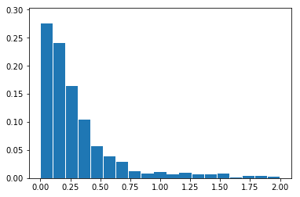

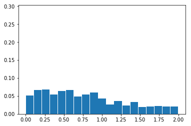

```python
count = len(predicted_df.error_relative)
hist_predicted = np.histogram(predicted_df.error_relative, np.linspace(0, 2, 20))
normalized_hist_predicted = hist_predicted[0]/count
hist_baseline = np.histogram(predicted_df.error_baseline_relative, np.linspace(0, 2, 20))
normalized_hist_baseline = hist_baseline[0]/count
centers = np.convolve(hist_predicted[1], [0.5, 0.5])
centers = centers[1:-1]
plt.bar(centers, normalized_hist_predicted, width=(centers[1]-centers[0])*0.95)
ylim = max(hist_predicted[0]/count) * 1.1
plt.ylim(0, ylim)
plt.show()
plt.bar(centers, normalized_hist_baseline, width=(centers[1]-centers[0])*0.95)
plt.ylim(0, ylim)
plt.show()
```

#### Accumulated

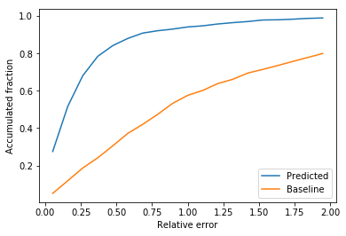

```python
def accumulated_distribution(histogram):
    accumulated = []
    total = 0
    for value in histogram:
        total += value
        accumulated.append(total)
    return accumulated


plt.plot(centers, accumulated_distribution(normalized_hist_predicted), label='Predicted')
plt.plot(centers, accumulated_distribution(normalized_hist_baseline), label='Baseline')
plt.xlabel('Relative error')
plt.ylabel('Accumulated fraction')
plt.legend(loc='lower right')
plt.show()
```

### Joined data summary

```python
predicted_df.describe(percentiles=[0.25, 0.5, 0.75, 0.85, 0.9, 0.95, 0.99])
```

|  | error | error_baseline | error_baseline_relative | error_relative | prediction | sha256_id | target |
| --- | --- | --- | --- | --- | --- | --- | --- |
| count | 1831.000000 | 1831.000000 | 1831.000000 | 1831.000000 | 1831.000000 | 1.831000e+03 | 1831.000000 |
| mean | 24.724444 | 61.209917 | 1.347101 | 0.339662 | 70.409178 | 2.093174e+09 | 74.776980 |
| std | 88.612458 | 154.054577 | 1.525956 | 0.545530 | 119.041930 | 1.251256e+09 | 165.736469 |
| min | 0.000800 | 0.018856 | 0.000265 | 0.000025 | 10.618600 | 6.276120e+06 | 2.900000 |
| 25% | 3.602500 | 25.406144 | 0.434397 | 0.095058 | 29.231500 | 9.932226e+08 | 25.900000 |
| 50% | 8.209800 | 39.071144 | 0.884096 | 0.201021 | 38.301400 | 2.068594e+09 | 38.510000 |
| 75% | 16.990600 | 50.281144 | 1.748307 | 0.375417 | 61.315800 | 3.141576e+09 | 62.545000 |
| 85% | 26.402700 | 57.191144 | 2.391193 | 0.548383 | 92.026100 | 3.628307e+09 | 92.310000 |
| 90% | 37.859200 | 62.608856 | 2.868540 | 0.703729 | 123.990600 | 3.844396e+09 | 125.800000 |
| 95% | 70.906800 | 128.913856 | 4.120946 | 1.167720 | 188.746900 | 4.066051e+09 | 200.095000 |
| 99% | 403.674620 | 742.743856 | 6.997881 | 2.015605 | 661.779180 | 4.235246e+09 | 813.925000 |
| max | 1860.852200 | 2459.888856 | 23.545222 | 7.886588 | 1475.172400 | 4.290291e+09 | 2531.070000 |

### Visualize decision tree

```python
# Pull out one tree from the forest
tree = rf.estimators_[0]
# Export the image to a dot file
export_graphviz(tree, out_file = 'tree.dot',
                feature_names = feature_list, rounded = True)
# Use dot file to create a graph
(graph, ) = pydot.graph_from_dot_file('tree.dot')
# Write graph to a png file
graph.write_png('tree.png')
```

[figure not shown]